# SEGMENTACIÓN DE CLIENTES CORPORATIVOS DE UNA EMPRESA

Carlos Mario Calle González

Catherine Andrea Córdoba Espinosa

Allison Piedrahita García

Santiago Ramírez Zapata

Jhonier Santiago Serna Cardona

03/08/2021

**Objetivo**: Realizar la segmentación de clientes para una empresa cuyos clientes son otras empresas. Explorar las relaciones entre las variables y una posible agrupación de las mismas según sus características.

### Introducción

Las técnicas de segmentación son una herramienta importante a la hora de trabajar con volúmenes considerables de información referente a diferentes tipos de clientes que hacen parte de un mercado. Esto se debe a que no todos son iguales ni tienen las mismas necesidades, razón por la cual es fundamental conocer las características relevantes de cada uno para agrupar perfiles afines, con el fin de lograr una mejor atención, fidelización de los clientes, tomar decisiones estratégicas y de marketing, ahorrar tiempo y mejorar el rendimiento, entre muchos otros beneficios.

### Contextualización

**Materiales**: Se analizó una base de datos con $2233$ usuarios y $46$ variables en total, las cuales se dividen en 2 grupos principales:

- **Variables de comportamiento de los clientes en canales y productos**: Consta de $30$ variables, divididas en *entradas* y *salidas* según la siguiente nomenclatura:
  - $en$: Entrada
  - $sal$: Salida
  - $vm$: Valor medio anual
  - $tx$: Transacciones mensuales promedio

  A continuación se ilustran algunos ejemplos teniendo en cuenta lo mencionado:
  - **en_vm_canalX**: valor del ticket promedio de entrada por el canal X
  - **en_tx_canalX**: cantidad de transacciones mensuales de entrada en promedio por el canal X
  - **sal_vm_canalX**: valor del ticket promedio de salida por el canal X
  - **sal_tx_canalX**: cantidad de transacciones mensuales de salida en promedio por el canal X

```r
datos_completos <- select(datos_completos, -c(recaudos_pj, recaudos_pn))
attach(datos_completos)
```

### Análisis descriptivo

se obtienen las medidas de tendencia central y de dispersión de las variables mencionadas y las correlaciones por pares.

#### **Variables de comportamiento de los clientes en canales y productos:**

|  | Media | Mínimo | Máximo | Desviación estándar | Mediana | Cuartil 1 | Cuartil 3 |
| --- | --- | --- | --- | --- | --- | --- | --- |
| en_vm_canal1 | 1853339861.57936 | 0 | 251092000000 | 8628981165.805 | 348671476.3 | 51375043.18 | 1229572057 |
| en_vm_canal2 | 5073029898.10303 | 0 | 695285000000 | 24206266499.3976 | 961172220.4 | 224638524.9 | 3113984333 |
| en_vm_canal3 | 198004356.270184 | 0 | 52076541969 | 1897338471.79433 | 1262783.8 | 0 | 8258949.08 |
| en_vm_canal4 | 436748914.527815 | 0 | 405096000000 | 9285151413.42273 | 0 | 0 | 3714011 |
| en_vm_canal5 | 2120246761.2266 | 0 | 806965000000 | 22701611794.854 | 4216583.25 | 0 | 300000000 |
| en_vm_canal6 | 123493933.189575 | 0 | 14523636565 | 684937881.19081 | 9021176.6 | 598340 | 47119545.42 |
| en_vm_canal7 | 1066323114.71303 | 0 | 770542000000 | 19989861716.8049 | 0 | 0 | 0 |
| en_vm_canal8 | 28877320.6632736 | 0 | 10038465888 | 242770315.648203 | 1908552.2 | 0 | 7916393.75 |
| en_vm_canal9 | 12474333.6418316 | 0 | 5408476569 | 124773188.637084 | 1509494.67 | 0 | 7011999 |
| en_vm_canal10 | 986298.074370802 | 0 | 180475245 | 6351148.93681142 | 0 | 0 | 0 |

[output cut: 20 more lines]

##### **Diagrama de correlación de las variables de comportamiento de los clientes en canales y productos**

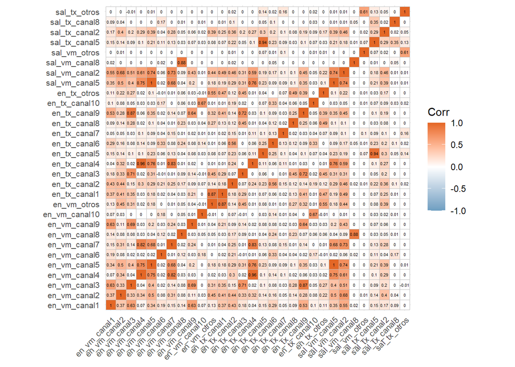

#### **Variables de estados financieros y características de los clientes:**

|  | Categoría 1 | Categoría 2 | Categoría 3 | Categoria 4 | Categoria 5 | Categoria 6 |
| --- | --- | --- | --- | --- | --- | --- |
| impo_cv | 824 | 828 | 306 | 229 | 46 | 0 |
| expo_vt | 824 | 1225 | 184 | 0 | 0 | 0 |
| cxp | 487 | 729 | 362 | 162 | 102 | 391 |
| cxc | 324 | 543 | 414 | 180 | 164 | 608 |
| totalinventory | 379 | 579 | 368 | 215 | 150 | 542 |
| rotacion_cxp | 825 | 626 | 324 | 458 | 0 | 0 |
| ciclo_negocio | 152 | 269 | 291 | 511 | 450 | 560 |
| ciclo_financiero | 269 | 315 | 350 | 282 | 433 | 584 |

| Tiendas físicas | Tiendas electrónicas | Frecuencias |
| --- | --- | --- |
| 0 | 0 | 1150 |
| 1 | 0 | 971 |
| 0 | 1 | 21 |
| 1 | 1 | 91 |

|  | Media | Mínimo | Máximo | Desviación estándar | Mediana | Cuartil 1 | Cuartil 3 |
| --- | --- | --- | --- | --- | --- | --- | --- |
| pagos_pj | 0.539250335871026 | 0 | 1 | 0.284742159242553 | 0.524 | 0.316 | 0.774 |
| pagos_pn | 0.440606806986117 | 0 | 1 | 0.281224800365723 | 0.46 | 0.2 | 0.665 |
| rotacion_inventarios | 3.09270040304523 | 1 | 6 | 1.90074158049188 | 3 | 1 | 5 |
| rotacion_cxc | 2.41110613524407 | 1 | 4 | 1.15170991932962 | 2 | 1 | 4 |

##### **Diagrama de correlación de las variables de estados financieros y características de los clientes**

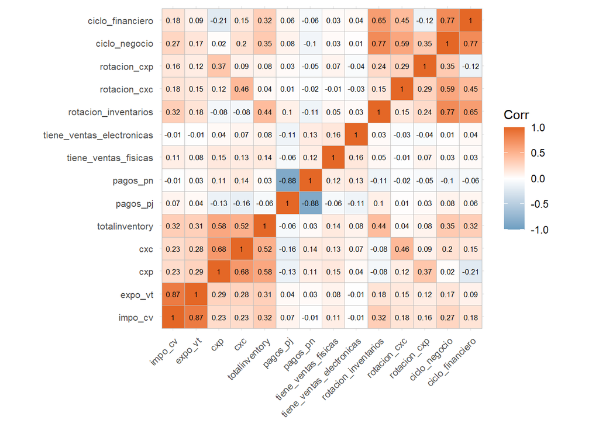

### Desarrollo estadístico

#### 1. Selección y procesamiento de variables

En primer lugar, se eliminarón las variables `recaudos_pn` y `recaudos_pj`, porque no contenían información relevante, pues eran una constante igual a $0$. Por el lado de las variables de estados financieros, se eliminan las variables `rotacion_inventarios`, `rotacion_cxc` y `rotacion_cxp`, puesto que desde el punto de vista contable estas se pueden resumir en las variables `ciclo_negocio` y `ciclo_financiero`. Adicionalmente, se realiza una estandarización a las variables cuantitativas denominadas como $Variables~~de~~comportamiento~~de~~los~~clientes~~en~~canales~~y~~productos$, para cada una de las observaciones de estas variables se asigna uno de los cuartiles dependiendo el valor que dicha observación tenga. Lo anterior, se hace con el fin de obtener una mejor segmentación de los datos más adelante. Con esta estandarización, el conjunto de variables queda compuesto por variables categóricas ordinales y binarias.

El resultado obtenido para la base de datos se muestra a continuación:

```r
kable(summary(datos_cluster), caption = "NÚMERO DE OBSERVACIÓNES PARA CADA VARIABLE EN CADA CUARTIL")
```

NÚMERO DE OBSERVACIÓNES PARA CADA VARIABLE EN CADA CUARTIL

|  | en_vm_canal1 | en_vm_canal2 | en_vm_canal3 | en_vm_canal4 | en_vm_canal5 | en_vm_canal6 | en_vm_canal7 | en_vm_canal8 | en_vm_canal9 | en_vm_canal10 | en_vm_otros | en_tx_canal1 | en_tx_canal2 | en_tx_canal3 | en_tx_canal4 | en_tx_canal5 | en_tx_canal6 | en_tx_canal7 | en_tx_canal8 | en_tx_canal9 | en_tx_canal10 | en_tx_otros | sal_vm_canal5 | sal_vm_canal2 | sal_vm_canal8 | sal_vm_otros | sal_tx_canal5 | sal_tx_canal2 | sal_tx_canal8 | … |
| --- | --- | --- | --- | --- | --- | --- | --- | --- | --- | --- | --- | --- | --- | --- | --- | --- | --- | --- | --- | --- | --- | --- | --- | --- | --- | --- | --- | --- | --- | --- |
|  | 1:559 | 1:559 | 1:705 | 1:1591 | 1:1032 | 1:559 | 1:2028 | 1:723 | 1:727 | 1:1998 | 1:1829 | 1:559 | 1:560 | 1:705 | 1:1591 | 1:1032 | 1:560 | 1:2028 | 1:723 | 1:727 | 1:1998 | 1:1829 | 1:1107 | 1:559 | 1:1936 | 1:2147 | 1:1107 | 1:562 | 1:1936 | … |
|  | 2:558 | 2:558 | 2:412 | 2: 84 | 2: 85 | 2:558 | 2: 205 | 2:394 | 2:390 | 2: 235 | 2: 404 | 2:558 | 2:558 | 2:412 | 2: 84 | 2: 148 | 2:558 | 2: 205 | 2:399 | 2:450 | 2: 235 | 2: 404 | 2: 10 | 2:558 | 2: 297 | 2: 86 | 2: 128 | 2:555 | 2: 297 | … |
|  | 3:558 | 3:558 | 3:558 | 3: 558 | 3: 559 | 3:558 | 3: 0 | 3:558 | 3:558 | 3: 0 | 3: 0 | 3:558 | 3:557 | 3:559 | 3: 558 | 3: 496 | 3:560 | 3: 0 | 3:553 | 3:498 | 3: 0 | 3: 0 | 3: 558 | 3:558 | 3: 0 | 3: 0 | 3: 441 | 3:558 | 3: 0 | … |
|  | 4:558 | 4:558 | 4:558 | 4: 0 | 4: 557 | 4:558 | 4: 0 | 4:558 | 4:558 | 4: 0 | 4: 0 | 4:558 | 4:558 | 4:557 | 4: 0 | 4: 557 | 4:555 | 4: 0 | 4:558 | 4:558 | 4: 0 | 4: 0 | 4: 558 | 4:558 | 4: 0 | 4: 0 | 4: 557 | 4:558 | 4: 0 | … |
|  | NA | NA | NA | NA | NA | NA | NA | NA | NA | NA | NA | NA | NA | NA | NA | NA | NA | NA | NA | NA | NA | NA | NA | NA | NA | NA | NA | NA | NA | … |
|  | NA | NA | NA | NA | NA | NA | NA | NA | NA | NA | NA | NA | NA | NA | NA | NA | NA | NA | NA | NA | NA | NA | NA | NA | NA | NA | NA | NA | NA | … |

#### 2. Agrupación

Una vez se ha procesado la base de datos con que se trabajará y se ha establecido la forma de los datos, se procede con el análisis para segmentar a los clientes corporativos. Para cumplir con lo anterior, en primer lugar se debe tener alguna medida de similitudes o disimilitudes entre las variables, por ello se calcula la distancia de Gower (1971), pues esta permite trabajar tanto con variables númericas como categóricas. Una forma sencilla de ver esta distancia es que para cada uno de los tipos de variables se usa una medida de distancia particular que funcione para ese tipo y se escala dicha distancia entre 0 y 1. Posteriormente, se calcula la combinación lineal especificando los pesos de cada uno de los componentes de la combinación lineal (una forma sencilla es usar el promedio), finalmente con esto se crea la matriz de distancias.

Las medidas que se usan para cada tipo de variable se describen a continuación:

- Cuantitativa: se calcula la distancia de Manhattan normalizada por rangos.
- Ordinal: en primer lugar, se clasifica la variable, luego se calcula la distancia Manhattan, con un ajuste especial para los empates.
- Nominal: las k categorías de la variable se convierte en k columnas binarias y posteriormente se usa el coeficiente de Dice.

Este método es sensible a la no normalidad y a datos atípicos, por lo que la transformación de las variables son un paso necesario como parte del preprocesamiento de datos [1].

```r
dist_gower <- daisy(datos_cluster,metric = "gower")
d <- summary(dist_gower)
d <- d$summ
d <- t(d)[,c(1:6)]
kable(d, col.names ="Valor", align = 'c', caption = "Medidas de tendencia para la distancia de Gower")
```

Medidas de tendencia para la distancia de Gower

|  | Valor |
| --- | --- |
| Min. | 0.00000 |
| 1st Qu. | 0.26504 |
| Median | 0.34106 |
| Mean | 0.35222 |
| 3rd Qu. | 0.42683 |
| Max. | 0.91707 |

Haciendo agrupamiento jerarquico/aglomerativo, utilizando el método $complete$ para medir distancias entre grupos, se obtiene lo siguiente:

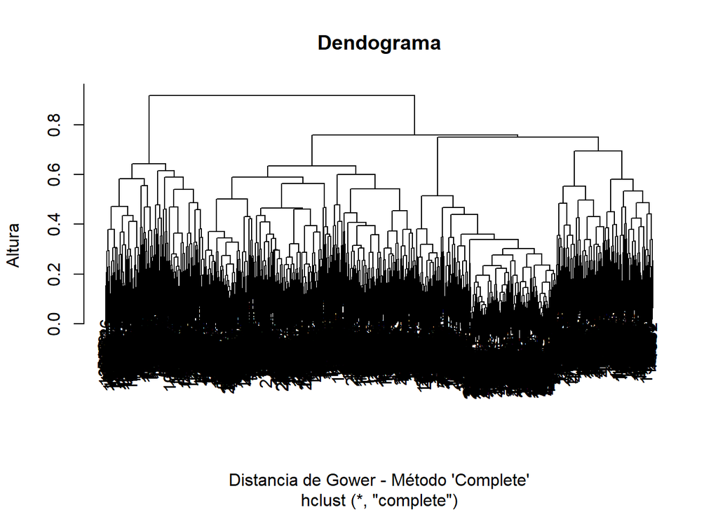

```r
cluster_jerar <- hclust(dist_gower,method = "complete")
plot(cluster_jerar, main = "Dendograma", ylab = "Altura", xlab = "Distancia de Gower - Método 'Complete'")
```

De acuerdo al gráfico, se identifican varios cortes de altura para seleccionar la cantidad de grupos teniendo en cuenta que a mayor cantidad más difícil puede llegar a ser la administración de dichos grupos, por lo cual se tienen en cuenta hasta cinco grupos para el análisis.

```r
etiqueta_grupo2 <- cutree(cluster_jerar,k=2)
kable(table(etiqueta_grupo2), col.names = c("Grupo", "Cantidad de usuarios"), align = 'c')
```

| Grupo | Cantidad de usuarios |
| --- | --- |
| 1 | 1828 |
| 2 | 405 |

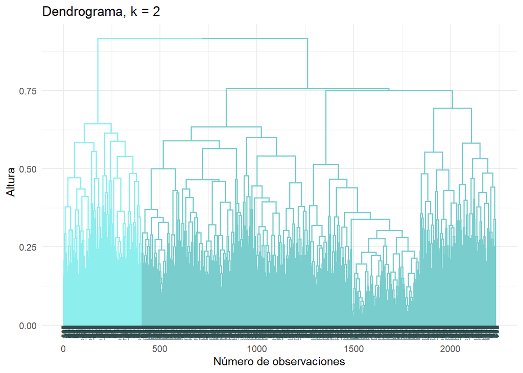

```r
dendro <- as.dendrogram(cluster_jerar)
dendro.col <- dendro %>%
  set("branches_k_color", k = 2, value =   c("darkslategray2", "darkslategray3")) %>%
  set("branches_lwd", 0.6) %>%
  set("labels_colors",
      value = c("darkslategray")) %>%
  set("labels_cex", 0.5)
ggd1 <- as.ggdend(dendro.col)
ggplot(ggd1, theme = theme_minimal()) +
  labs(x = "Número de observaciones", y = "Altura", title = "Dendrograma, k = 2")
```

```r
etiqueta_grupo3 <- cutree(cluster_jerar,k=3)
kable(table(etiqueta_grupo3), col.names = c("Grupo", "Cantidad de usuarios"), align = 'c')
```

| Grupo | Cantidad de usuarios |
| --- | --- |
| 1 | 964 |
| 2 | 405 |
| 3 | 864 |

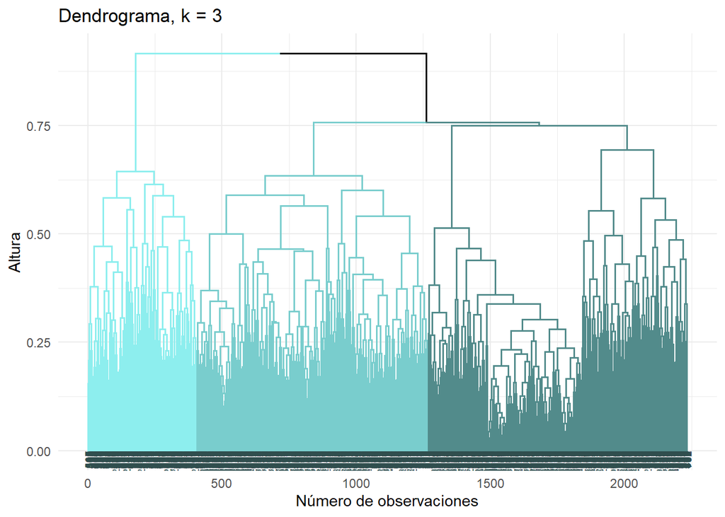

```r
dendro <- as.dendrogram(cluster_jerar)
dendro.col <- dendro %>%
  set("branches_k_color", k = 3, value =   c("darkslategray2", "darkslategray3", "darkslategray4")) %>%
  set("branches_lwd", 0.6) %>%
  set("labels_colors",
      value = c("darkslategray")) %>%
  set("labels_cex", 0.5)
ggd1 <- as.ggdend(dendro.col)
ggplot(ggd1, theme = theme_minimal()) +
  labs(x = "Número de observaciones", y = "Altura", title = "Dendrograma, k = 3")
```

```r
etiqueta_grupo4 <- cutree(cluster_jerar,k=4)
kable(table(etiqueta_grupo4), col.names = c("Grupo", "Cantidad de usuarios"), align = 'c')
```

| Grupo | Cantidad de usuarios |
| --- | --- |
| 1 | 570 |
| 2 | 394 |
| 3 | 405 |
| 4 | 864 |

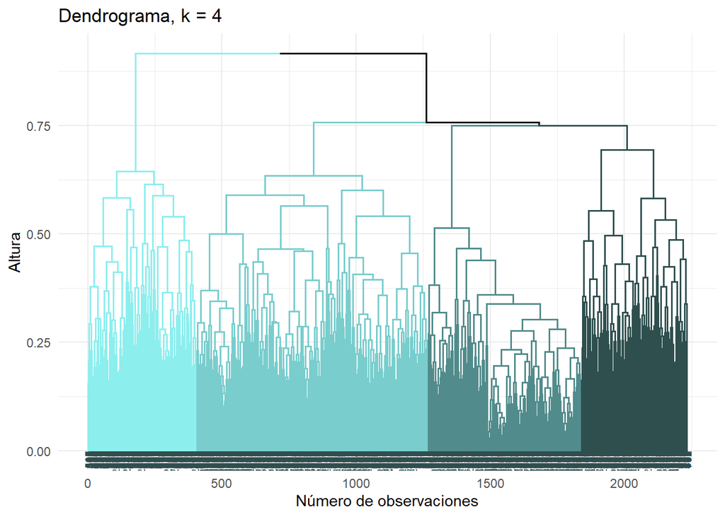

```r
dendro <- as.dendrogram(cluster_jerar)
dendro.col <- dendro %>%
  set("branches_k_color", k = 4, value =   c("darkslategray2", "darkslategray3", "darkslategray4","darkslategray")) %>%
  set("branches_lwd", 0.6) %>%
  set("labels_colors",
      value = c("darkslategray")) %>%
  set("labels_cex", 0.5)
ggd1 <- as.ggdend(dendro.col)
ggplot(ggd1, theme = theme_minimal()) +
  labs(x = "Número de observaciones", y = "Altura", title = "Dendrograma, k = 4")
```

```r
etiqueta_grupo5 <- cutree(cluster_jerar,k=5)
kable(table(etiqueta_grupo5), col.names = c("Grupo", "Cantidad de usuarios"), align = 'c')
```

| Grupo | Cantidad de usuarios |
| --- | --- |
| 1 | 570 |
| 2 | 197 |
| 3 | 197 |
| 4 | 405 |
| 5 | 864 |

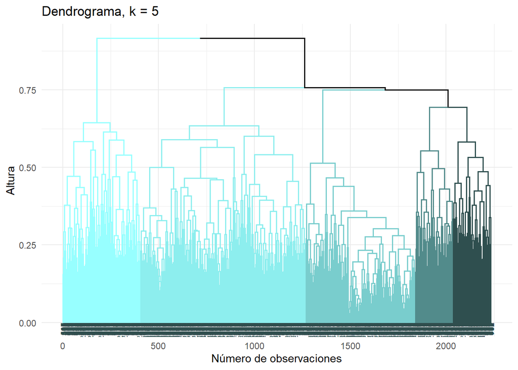

```r
dendro <- as.dendrogram(cluster_jerar)
dendro.col <- dendro %>%
  set("branches_k_color", k = 5, value =   c("darkslategray1","darkslategray2", "darkslategray3", "darkslategray4","darkslategray")) %>%
  set("branches_lwd", 0.6) %>%
  set("labels_colors",
      value = c("darkslategray")) %>%
  set("labels_cex", 0.5)
ggd1 <- as.ggdend(dendro.col)
ggplot(ggd1, theme = theme_minimal()) +
  labs(x = "Número de observaciones", y = "Altura", title = "Dendrograma, k = 5")
```

De las gráficas anteriores, se observa que: - Para k=2 se obtienen dos grupos desproporcionados debido a que uno de ellos queda con una cantidad de usuarios de 1828 y el otro con 405. - Para k=3 se obtienen tres grupos medianamente proporcionados en los que se distribuye la cantidad de usarios en 964, 405 y 864. - Para k=4 se obtienen cuatro grupos proporcionados en los que se distribuyen los usuarios en 570, 394, 405 y 864. - Para k=5 se obtiene lo mismo de k=4 con la diferencia que el grupo 2 se divide en dos partes iguales volviendo un poco desequilibrados los grupos.

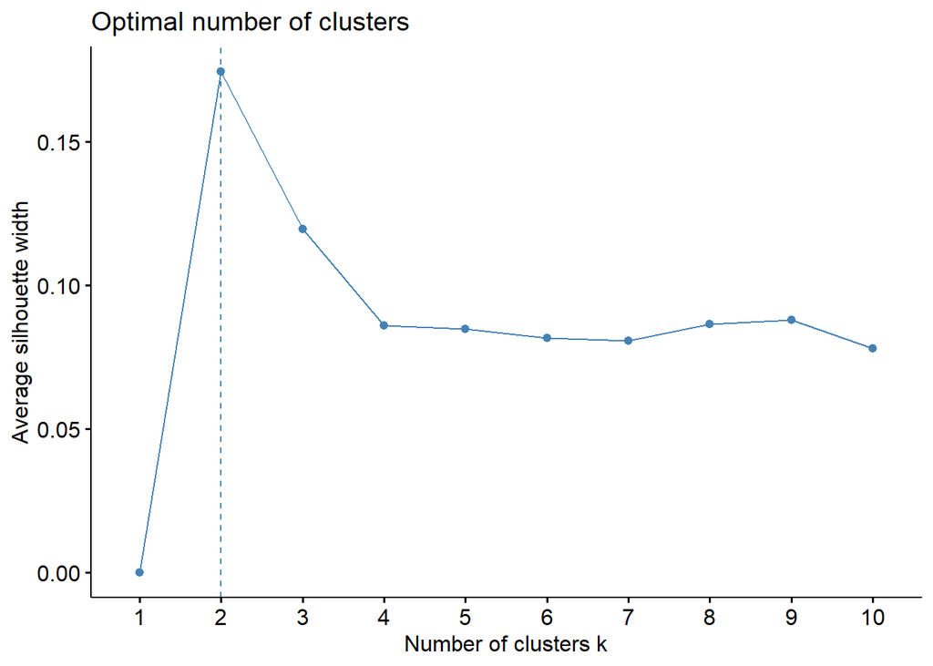

```r
library(factoextra)
fviz_nbclust(datos_cluster, FUN = hcut, method = "silhouette")
```

#### 3. Caracterización estadística de los grupos seleccionados

Para cada uno de los grupos, se realiza una tabla descriptiva teniendo en cuenta cada una de las variables de la base de datos, así:

$GRUPO~~1$

```r
library(DT)
descripcion <- summary(datos_cluster[etiqueta_grupo4==1,])
descripcion <- as.data.frame(descripcion)
descripcion$Var1 <- rep.int(1:6,nrow(descripcion)/6)

descripcion$Freq <- as.character(descripcion$Freq)
descripcion$Freq <- sapply(strsplit(descripcion$Freq, split=':', fixed=TRUE), function(x) (x[2]))
descripcion$Freq <- lapply(descripcion$Freq,trimws)
descripcion$Freq <- as.integer(descripcion$Freq)
descripcion$Freq <- ifelse(is.na(descripcion$Freq), '', descripcion$Freq)

grupo1 <- pivot_wider(descripcion,names_from = Var2,values_from = Freq)

#formattable(grupo1,list( grupo1[,]= color_tile("#DeF7E9", "#71CA97")))

formattable(grupo1, sapply(names(grupo1), function(row) {
  row = color_tile("#DeF7E9", "#71CA97")
})) %>%
  as.datatable(escape = FALSE,
               options = list(scrollX = TRUE,paging = FALSE,searching = FALSE, ordering = FALSE),
               rownames = FALSE)
```

| Var1 | en_vm_canal1 | en_vm_canal2 | en_vm_canal3 | en_vm_canal4 | en_vm_canal5 | en_vm_canal6 | en_vm_canal7 | en_vm_canal8 | en_vm_canal9 | en_vm_canal10 | en_vm_otros | en_tx_canal1 | en_tx_canal2 | en_tx_canal3 | en_tx_canal4 | en_tx_canal5 | en_tx_canal6 | en_tx_canal7 | en_tx_canal8 | en_tx_canal9 | en_tx_canal10 | en_tx_otros | sal_vm_canal5 | sal_vm_canal2 | sal_vm_canal8 | sal_vm_otros | sal_tx_canal5 | sal_tx_canal2 | sal_tx_canal8 | … |
| --- | --- | --- | --- | --- | --- | --- | --- | --- | --- | --- | --- | --- | --- | --- | --- | --- | --- | --- | --- | --- | --- | --- | --- | --- | --- | --- | --- | --- | --- | --- |
| 1 | 391 | 339 | 389 | 519 | 548 | 386 | 552 | 455 | 449 | 570 | 553 | 412 | 384 | 389 | 519 | 548 | 397 | 552 | 455 | 449 | 570 | 553 | 554 | 320 | 569 | 564 | 554 | 317 | 569 | … |
| 2 | 130 | 111 | 98 | 6 | 10 | 125 | 18 | 59 | 73 | 0 | 17 | 142 | 151 | 101 | 6 | 16 | 140 | 18 | 76 | 96 | 0 | 17 | 1 | 137 | 1 | 6 | 12 | 140 | 1 | … |
| 3 | 43 | 78 | 72 | 45 | 11 | 52 | 0 | 46 | 42 | 0 | 0 | 16 | 30 | 68 | 45 | 6 | 32 | 0 | 30 | 21 | 0 | 0 | 14 | 87 | 0 | 0 | 3 | 71 | 0 | … |
| 4 | 6 | 42 | 11 | 0 | 1 | 7 | 0 | 10 | 6 | 0 | 0 | 0 | 5 | 12 | 0 | 0 | 1 | 0 | 9 | 4 | 0 | 0 | 1 | 26 | 0 | 0 | 1 | 42 | 0 | … |
| 5 |  |  |  |  |  |  |  |  |  |  |  |  |  |  |  |  |  |  |  |  |  |  |  |  |  |  |  |  |  | … |
| 6 |  |  |  |  |  |  |  |  |  |  |  |  |  |  |  |  |  |  |  |  |  |  |  |  |  |  |  |  |  | … |

$GRUPO~~2$

```r
descripcion <- summary(datos_cluster[etiqueta_grupo4==2,])
descripcion <- as.data.frame(descripcion)
descripcion$Var1 <- rep.int(1:6,nrow(descripcion)/6)

descripcion$Freq <- as.character(descripcion$Freq)
descripcion$Freq <- sapply(strsplit(descripcion$Freq, split=':', fixed=TRUE), function(x) (x[2]))
descripcion$Freq <- lapply(descripcion$Freq,trimws)
descripcion$Freq <- as.integer(descripcion$Freq)
descripcion$Freq <- ifelse(is.na(descripcion$Freq), '', descripcion$Freq)

grupo1 <- pivot_wider(descripcion,names_from = Var2,values_from = Freq)

#formattable(grupo1,list( grupo1[,]= color_tile("#DeF7E9", "#71CA97")))

formattable(grupo1, sapply(names(grupo1), function(row) {
  row = color_tile("#DeF7E9", "#71CA97")
})) %>%
  as.datatable(escape = FALSE,
               options = list(scrollX = TRUE,paging = FALSE,searching = FALSE, ordering = FALSE),
               rownames = FALSE)
```

| Var1 | en_vm_canal1 | en_vm_canal2 | en_vm_canal3 | en_vm_canal4 | en_vm_canal5 | en_vm_canal6 | en_vm_canal7 | en_vm_canal8 | en_vm_canal9 | en_vm_canal10 | en_vm_otros | en_tx_canal1 | en_tx_canal2 | en_tx_canal3 | en_tx_canal4 | en_tx_canal5 | en_tx_canal6 | en_tx_canal7 | en_tx_canal8 | en_tx_canal9 | en_tx_canal10 | en_tx_otros | sal_vm_canal5 | sal_vm_canal2 | sal_vm_canal8 | sal_vm_otros | sal_tx_canal5 | sal_tx_canal2 | sal_tx_canal8 | … |
| --- | --- | --- | --- | --- | --- | --- | --- | --- | --- | --- | --- | --- | --- | --- | --- | --- | --- | --- | --- | --- | --- | --- | --- | --- | --- | --- | --- | --- | --- | --- |
| 1 | 26 | 71 | 44 | 44 | 169 | 34 | 319 | 51 | 33 | 341 | 293 | 8 | 23 | 44 | 44 | 169 | 24 | 319 | 51 | 33 | 341 | 293 | 179 | 66 | 359 | 385 | 179 | 69 | 359 | … |
| 2 | 123 | 131 | 92 | 47 | 12 | 115 | 75 | 102 | 96 | 53 | 101 | 87 | 91 | 85 | 45 | 25 | 96 | 75 | 83 | 95 | 53 | 101 | 0 | 118 | 35 | 9 | 20 | 102 | 35 | … |
| 3 | 156 | 127 | 132 | 303 | 113 | 134 | 0 | 150 | 148 | 0 | 0 | 187 | 158 | 140 | 305 | 102 | 143 | 0 | 152 | 136 | 0 | 0 | 118 | 137 | 0 | 0 | 89 | 134 | 0 | … |
| 4 | 89 | 65 | 126 | 0 | 100 | 111 | 0 | 91 | 117 | 0 | 0 | 112 | 122 | 125 | 0 | 98 | 131 | 0 | 108 | 130 | 0 | 0 | 97 | 73 | 0 | 0 | 106 | 89 | 0 | … |
| 5 |  |  |  |  |  |  |  |  |  |  |  |  |  |  |  |  |  |  |  |  |  |  |  |  |  |  |  |  |  | … |
| 6 |  |  |  |  |  |  |  |  |  |  |  |  |  |  |  |  |  |  |  |  |  |  |  |  |  |  |  |  |  | … |

$GRUPO ~~ 3$

```r
descripcion <- summary(datos_cluster[etiqueta_grupo4==3,])
descripcion <- as.data.frame(descripcion)
descripcion$Var1 <- rep.int(1:6,nrow(descripcion)/6)

descripcion$Freq <- as.character(descripcion$Freq)
descripcion$Freq <- sapply(strsplit(descripcion$Freq, split=':', fixed=TRUE), function(x) (x[2]))
descripcion$Freq <- lapply(descripcion$Freq,trimws)
descripcion$Freq <- as.integer(descripcion$Freq)
descripcion$Freq <- ifelse(is.na(descripcion$Freq), '', descripcion$Freq)

grupo1 <- pivot_wider(descripcion,names_from = Var2,values_from = Freq)

#formattable(grupo1,list( grupo1[,]= color_tile("#DeF7E9", "#71CA97")))

formattable(grupo1, sapply(names(grupo1), function(row) {
  row = color_tile("#DeF7E9", "#71CA97")
})) %>%
  as.datatable(escape = FALSE,
               options = list(scrollX = TRUE,paging = FALSE,searching = FALSE, ordering = FALSE),
               rownames = FALSE)
```

| Var1 | en_vm_canal1 | en_vm_canal2 | en_vm_canal3 | en_vm_canal4 | en_vm_canal5 | en_vm_canal6 | en_vm_canal7 | en_vm_canal8 | en_vm_canal9 | en_vm_canal10 | en_vm_otros | en_tx_canal1 | en_tx_canal2 | en_tx_canal3 | en_tx_canal4 | en_tx_canal5 | en_tx_canal6 | en_tx_canal7 | en_tx_canal8 | en_tx_canal9 | en_tx_canal10 | en_tx_otros | sal_vm_canal5 | sal_vm_canal2 | sal_vm_canal8 | sal_vm_otros | sal_tx_canal5 | sal_tx_canal2 | sal_tx_canal8 | … |
| --- | --- | --- | --- | --- | --- | --- | --- | --- | --- | --- | --- | --- | --- | --- | --- | --- | --- | --- | --- | --- | --- | --- | --- | --- | --- | --- | --- | --- | --- | --- |
| 1 | 0 | 10 | 18 | 192 | 69 | 3 | 317 | 2 | 2 | 249 | 176 | 0 | 6 | 18 | 192 | 69 | 2 | 317 | 2 | 2 | 249 | 176 | 98 | 26 | 204 | 367 | 98 | 26 | 204 | … |
| 2 | 17 | 47 | 35 | 13 | 13 | 24 | 88 | 24 | 16 | 156 | 229 | 2 | 25 | 32 | 14 | 21 | 12 | 88 | 14 | 11 | 156 | 229 | 1 | 47 | 201 | 38 | 17 | 56 | 201 | … |
| 3 | 79 | 111 | 100 | 200 | 118 | 80 | 0 | 73 | 84 | 0 | 0 | 83 | 79 | 110 | 199 | 97 | 71 | 0 | 69 | 91 | 0 | 0 | 95 | 90 | 0 | 0 | 87 | 98 | 0 | … |
| 4 | 309 | 237 | 252 | 0 | 205 | 298 | 0 | 306 | 303 | 0 | 0 | 320 | 295 | 245 | 0 | 218 | 320 | 0 | 320 | 301 | 0 | 0 | 211 | 242 | 0 | 0 | 203 | 225 | 0 | … |
| 5 |  |  |  |  |  |  |  |  |  |  |  |  |  |  |  |  |  |  |  |  |  |  |  |  |  |  |  |  |  | … |
| 6 |  |  |  |  |  |  |  |  |  |  |  |  |  |  |  |  |  |  |  |  |  |  |  |  |  |  |  |  |  | … |

$GRUPO ~~ 4$

```r
descripcion <- summary(datos_cluster[etiqueta_grupo4==4,])
descripcion <- as.data.frame(descripcion)
descripcion$Var1 <- rep.int(1:6,nrow(descripcion)/6)

descripcion$Freq <- as.character(descripcion$Freq)
descripcion$Freq <- sapply(strsplit(descripcion$Freq, split=':', fixed=TRUE), function(x) (x[2]))
descripcion$Freq <- lapply(descripcion$Freq,trimws)
descripcion$Freq <- as.integer(descripcion$Freq)
descripcion$Freq <- ifelse(is.na(descripcion$Freq), '', descripcion$Freq)

grupo1 <- pivot_wider(descripcion,names_from = Var2,values_from = Freq)

#formattable(grupo1,list( grupo1[,]= color_tile("#DeF7E9", "#71CA97")))

formattable(grupo1, sapply(names(grupo1), function(row) {
  row = color_tile("#DeF7E9", "#71CA97")
})) %>%
  as.datatable(escape = FALSE,
               options = list(scrollX = TRUE,paging = FALSE,searching = FALSE, ordering = FALSE),
               rownames = FALSE)
```

| Var1 | en_vm_canal1 | en_vm_canal2 | en_vm_canal3 | en_vm_canal4 | en_vm_canal5 | en_vm_canal6 | en_vm_canal7 | en_vm_canal8 | en_vm_canal9 | en_vm_canal10 | en_vm_otros | en_tx_canal1 | en_tx_canal2 | en_tx_canal3 | en_tx_canal4 | en_tx_canal5 | en_tx_canal6 | en_tx_canal7 | en_tx_canal8 | en_tx_canal9 | en_tx_canal10 | en_tx_otros | sal_vm_canal5 | sal_vm_canal2 | sal_vm_canal8 | sal_vm_otros | sal_tx_canal5 | sal_tx_canal2 | sal_tx_canal8 | … |
| --- | --- | --- | --- | --- | --- | --- | --- | --- | --- | --- | --- | --- | --- | --- | --- | --- | --- | --- | --- | --- | --- | --- | --- | --- | --- | --- | --- | --- | --- | --- |
| 1 | 142 | 139 | 254 | 836 | 246 | 136 | 840 | 215 | 243 | 838 | 807 | 139 | 147 | 254 | 836 | 246 | 137 | 840 | 215 | 243 | 838 | 807 | 276 | 147 | 804 | 831 | 276 | 150 | 804 | … |
| 2 | 288 | 269 | 187 | 18 | 50 | 294 | 24 | 209 | 205 | 26 | 57 | 327 | 291 | 194 | 19 | 86 | 310 | 24 | 226 | 248 | 26 | 57 | 8 | 256 | 60 | 33 | 79 | 257 | 60 | … |
| 3 | 280 | 242 | 254 | 10 | 317 | 292 | 0 | 289 | 284 | 0 | 0 | 272 | 290 | 241 | 9 | 291 | 314 | 0 | 302 | 250 | 0 | 0 | 331 | 244 | 0 | 0 | 262 | 255 | 0 | … |
| 4 | 154 | 214 | 169 | 0 | 251 | 142 | 0 | 151 | 132 | 0 | 0 | 126 | 136 | 175 | 0 | 241 | 103 | 0 | 121 | 123 | 0 | 0 | 249 | 217 | 0 | 0 | 247 | 202 | 0 | … |
| 5 |  |  |  |  |  |  |  |  |  |  |  |  |  |  |  |  |  |  |  |  |  |  |  |  |  |  |  |  |  | … |
| 6 |  |  |  |  |  |  |  |  |  |  |  |  |  |  |  |  |  |  |  |  |  |  |  |  |  |  |  |  |  | … |

### Descripción de resultados

De los resultados estadísticos obtenidos anteriormente, se llega a:

**Grupo 1**: El comportamiento de los clientes segmentados en este grupo se describe de la siguiente manera:

- *Variables de comportamiento de los clientes en canales y productos*
  - En las entradas, el valor del ticket promedio se encuentra en el cuartil 1. De la misma manera, la cantidad de transacciones mensuales promedio se encuentran en el cuartil 1. De esto se puede concluir que a este grupo pertenecen aquellas empresas con valores más bajos de ingresos y con número de transacciones de entrada más bajas.
  - En las salidas, el valor del ticket promedio se encuentra en el cuartil 1. De la misma manera, la cantidad de transacciones mensuales promedio se encuentran en el cuartil 1. De lo anterior, se concluye que este grupo de empresas tienen los valores más bajos de egresos y número de transacciones de salida.

Podría pensarse entonces que las empresas pertenecientes a este grupo son micro, dado que sus movimientos o cantidad de transacciones por medio de entornos físicos y/o virtuales son bajos, ya sean de entrada o de salida. Podría intuirse que dado a su clasificación de tamaño, los ingresos y egresos son acordes, pues el valor de sus transacciones tanto de entrada como de salida son muy bajos dentro del total de clientes.

- *Variables de estados financieros y características de los clientes* Las importaciones dadas por compras y las exportaciones dadas por ventas en este grupo se clasifican en las categorias 1 y 2, lo cual se puede explicar en que como son microempresas tienen bajas cantidades tanto de importaciones como de exportaciones. Asimismo, las cuentas por pagar y las cuentas por cobrar también se encuentran dentro de las categorías 1 y 2 de donde se puede intuir que debido al tamaño de las empresas tienen poca cantidad de deudas a proveedores y/o de cuentas por cobrar con sus clientes. Sin embargo, estas empresas cuentan con ciclos financieros y de negocios entre las categorías 4, 5 y 6 lo cual indica un proceso lento para el ingreso de dinero a sus cuentas, el pago de proveedores y la adquisición de inventario, el cual, se encuentra en valores bajos, es decir, en la categoría 1 dado que son microempresas. Por otra parte, los pagos dentro de estas organizaciones se dan en mayor medida a personas jurídicas ya que esta variable se encuentra dentro de las categorías 3 y 4 mientras que las personas naturales se encuentra en las categorías 1 y 2. Finalmente, para este grupo se encuentra que no hay una preferencia para tiendas físicas o virtuales y que se encuentran aproximadamente en la misma proporción.

**Grupo 2**: El comportamiento de los clientes segmentados en este grupo se describe de la siguiente manera:

Este grupo se puede decir que está conformado por empresas pequeñas, pues posee una cantidad de transacciones de entrada con valores de transacciones medios, por lo que se puede pensar que tienen una mayor cantidad de ventas de productos y/o servicios comparadas con el grupo 1. Además, no suelen utilizar canales como el 7,10 y otros; y cuando lo hacen, el valor medio de sus transacciones se encuentra en el menor rango. Podría existir desconfianza para dichos canales por parte de las empresas. Además, podría afirmarse que son empresas con tendencias a valores bajos de deudas ya que el valor de las transacciones promedio de salida es bajo.

- *Variables de estados financieros y características de los clientes* Las importaciones dadas por compras y las exportaciones dadas por ventas en este grupo se clasifican en las categorias 1 y 2, lo cual se puede explicar en que son empresas pequeñas y por lo tanto tienen bajas cantidades tanto de importaciones como de exportaciones. Asimismo, las cuentas por pagar y las cuentas por cobrar también se encuentran dentro de las categorías 1 y 2 de donde se puede intuir que debido al tamaño de las empresas tienen poca cantidad de deudas a proveedores y/o de cuentas por cobrar con sus clientes. Sin embargo, estas empresas cuentan con ciclos financieros y de negocios entre las categorías 4, 5 y 6 lo cual indica un proceso lento para el ingreso de dinero a sus cuentas, el pago de proveedores y la adquisición de inventario, el cual, se encuentra en valores medios, es decir, en las categorías 2 y 3 dado que son empresas pequeñas. Por otra parte, los pagos dentro de estas organizaciones se dan en mayor medida a personas naturales ya que esta variable se encuentra dentro de la categoría 3 y 4 mientras que las personas jurídicas se encuentran en la categoría 2. Finalmente, para este grupo se encuentra que hay una preferencia en tiendas virtuales en lugar de físicas.

**Grupo 3**: El comportamiento de los clientes segmentados en este grupo se describe de la siguiente manera:

- *Variables de comportamiento de los clientes en canales y productos*
  - En las entradas, el valor del ticket promedio y la cantidad de transacciones mensuales promedio para este grupo se encuentra en el cuartil 4 para todos los canales a excepción del 7,10 y otros, que se encuentran en los cuartiles 1 y 2.
  - En las salidas, el valor del ticket promedio y la cantidad de transacciones mensuales promedio se encuentran dentro de los cuartiles 4, 1 y 2

Este grupo cuenta con empresas grandes, pues posee gran cantidad de transacciones promedio de entrada debido a que tienen mayores ventas de productos y/o servicios de alta calidad, pues poseen un valor de transacciones alto. Al igual que el grupo 2, estas empresas usan poco los canales 7,10 y otros para todo lo relacionado con las entradas, como por ejemplo recaudos y consignaciones. Podría decirse que existe desconfianza en el uso de dichos canales. Por otra parte, la cantidad de transacciones de salida y valor promedio de transacción son bajas para algunos canales y altos para otros. Esto se puede explicar en alguna preferencia de proveedores o canales por parte de estas empresas grandes.

- *Variables de estados financieros y características de los clientes* Las importaciones dadas por compras y las exportaciones dadas por ventas en este grupo se clasifican en la categoría 2, lo cual se puede explicar en que son empresas grandes que no se encuentran muy familiarizadas dentro del mercado internacional. Por otra parte, las cuentas por pagar y las cuentas por cobrar se encuentran dentro de la categoría 6 de donde se puede intuir que debido al tamaño de las empresas tienen una gran cantidad de deudas a proveedores y/o de cuentas por cobrar con sus clientes. Además, estas empresas cuentan con ciclos financieros y de negocios entre las categorías 4, 5 y 6 lo cual indica un proceso lento para el ingreso de dinero a sus cuentas, el pago de proveedores y la adquisición de inventario, el cual, se encuentra en valores altos, es decir, en la categoría 6 dado que son empresas grandes. Por otra parte, los pagos dentro de estas organizaciones se dan en mayor medida a personas naturales ya que esta variable se encuentra dentro de las categorías 3 y 4 mientras que las personas jurídicas se encuentran en las categorías 1 y 2. Finalmente, para este grupo se encuentra que hay una preferencia en tiendas virtuales en lugar de físicas.

**Grupo 4**: El comportamiento de los clientes segmentados en este grupo se describe de la siguiente manera:

Este grupo cuenta con empresas medianas que poseen una cantidad considerable de ventas de productos y/o servicios de alta calidad, pues cuentan con gran cantidad de entradas para la mayoría de sus canales con valores de transacción promedio elevados. Las empresas de este grupo también poseen desconfianza en los canales 7,10 y otros para todo lo relacionado con devoluciones, recaudos, consignaciones, entre otros; dado que la cantidad de transacciones y el valor de estas es bajo. De igual manera, existe desconfianza en el uso de dichos canales para transacciones de entrada importantes. Por otra parte, la cantidad de transacciones de salida y valor promedio de transacción son bajas para algunos canales y altos para otros. Esto se puede explicar en alguna preferencia de proveedores o canales por parte de estas empresas grandes.

- *Variables de estados financieros y características de los clientes* Las importaciones dadas por compras y las exportaciones dadas por ventas en este grupo se clasifican en las categorías 1 y 2, lo cual se puede explicar en que son empresas medianas que apenas están explorando el mercado internacional. Asimismo, las cuentas por pagar y las cuentas por cobrar se encuentran dentro de las categorías 1, 2 y 3 de donde se puede intuir que debido al tamaño de las empresas tienen una cantidad baja/media de deudas a proveedores y/o de cuentas por cobrar con sus clientes. Además, estas empresas cuentan con ciclos financieros y de negocios entre las categorías 5 y 6 lo cual indica un proceso lento para el ingreso de dinero a sus cuentas, el pago de proveedores y la adquisición de inventario, el cual, se encuentra en valores bajos/medios, es decir, en las categorías 1, 2 y 3 dado que son empresas medianas. Por otra parte, los pagos dentro de estas organizaciones se dan en igual medida a personas naturales y juríficas ya que esta variable se encuentra dentro de las categoría 3 y 4 mientras que las personas jurídicas se encuentran en las categorías 2, 3 y 4. Finalmente, para este grupo se encuentra que no hay una preferencia en tiendas virtuales o físicas y que se encuentran aproximadamente en la misma proporción.

En resumen se obtiene que:

```
1. Grupo 1: microempresas con bajos ingresos, egresos, cxp, cxc e inventarios, con altos ciclos financieros y de negocios, con mayor pago a personas jurídicas y sin preferencia en tiendas virtuales o físicas.
2. Grupo 2: empresas pequeñas con ingresos moderados y egresos bajos, con desconfianza en algunos canales, con bajos cxp, cxc e inventarios, con altos ciclos financieros y de negocios, con mayor pago a personas naturales y con preferencia en tiendas virtuales.
3. Grupo 3: empresas grandes con altos ingresos, egresos, cxp, cxc, inventarios, ciclos financieros y de negocios, con mayor pago a personas naturales y con preferencia a tiendas virtuales.
4. Grupo 4: empresas medianas con ingresos y egresos altos, con cxp, cxc e inventarios medios, altos ciclos financieros y de negocios, con igual pago a personas jurídicas y naturales y sin preferencia en tiendas virtuales o físicas.
```

### Referencias

[1]. https://www.rdocumentation.org/packages/cluster/versions/2.1.2/topics/daisy [2]. https://bookdown.org/dparedesi/data-science-con-r/aprendizaje-no-supervisado.html